# Orientalism in 19th Century Danish News Media

Kaarunya Mohanathas

## 1. Introduction

The aim of this project is to analyze orientalism in 19th century Danish news media through the use of text mining and sentiment analysis of digitized articles exported from Mediestream. For further detail, please read the project report.

### 1.1 Loading data

The following data have been accessed through the Mediestream API using the search string “Orienten AND py:[1800 TO 1880]”. Link to the API: http://labs.statsbiblioteket.dk/labsapi/api//api-docs?url=/labsapi/api/openapi.yaml#/

The dataset consists of Danish articles from the year 1800 to 1880 mentioning “Orienten”. Due to the large number of data used in this project, it may take a while for the document to fully load.

```r
art_orienten <- read_csv("http://labs.statsbiblioteket.dk/labsapi/api/aviser/export/fields?query=Orienten%20AND%20py%3A%5B1800%20TO%201880%5D&fields=link&fields=recordID&fields=timestamp&fields=pwa&fields=cer&fields=fulltext_org&fields=pageUUID&fields=editionUUID&fields=titleUUID&fields=editionId&fields=familyId&fields=newspaper_page&fields=newspaper_edition&fields=lplace&fields=location_name&fields=location_coordinates&max=-1&structure=header&structure=content&format=CSV")
```

## 2. Text mining

The first part of the data analysis is text mining.

### 2.1 Tidying data

The data exported from Mediestream need further tidying, as our objective is to analyze individual words. The first step is thus to use `unnest_tokens()` to split the column named `fulltext_org` into tokens representing individual words.

```r
art_orienten %>%
  unnest_tokens(word, fulltext_org) -> art_orienten_tidy
```

Let us examine a snippet (300 rows) of the dataframe sorted by count:

```r
art_orienten_tidy %>%
  count(word, sort = "TRUE") %>%
  head(300)
```

```
## # A tibble: 300 × 2
##    word       n
##    <chr>  <int>
##  1 i     680253
##  2 at    587276
##  3 og    564669
##  4 den   391244
##  5 til   374062
##  6 en    320869
##  7 det   315362
##  8 af    296717
##  9 de    279328
## 10 er    235744
## # ℹ 290 more rows
```

It is clear that the most frequent words are not of much use for the purpose of this particular project, as they are commonly used conjunctions and prepositions among others. The following step is therefore to exclude these words by creating a stopword list.

### 2.2 Stopwords

First, the words are sorted by count.

```r
art_orienten_tidy_count <- art_orienten_tidy %>%
  count(word, sort = "TRUE")
```

Next step is to extract a number of the most frequently used words, thereby creating a stopword list. 400 appears to be an apt number.

```r
top_words <- top_n(art_orienten_tidy_count, 400, n)

top_words
```

```
## # A tibble: 400 × 2
##    word       n
##    <chr>  <int>
##  1 i     680253
##  2 at    587276
##  3 og    564669
##  4 den   391244
##  5 til   374062
##  6 en    320869
##  7 det   315362
##  8 af    296717
##  9 de    279328
## 10 er    235744
## # ℹ 390 more rows
```

However, some of the words in the list above may still be of relevance to the analysis. The following step is thus to manually exclude any notable words from the stopword list, and in doing so include them in the data that is to be analyzed.

```r
top_words_manual <- top_words %>%
#  filter(word != "vilde") %>%
  filter(word != "fin") %>%
  filter(word != "god") %>%
  filter(word != "gode") %>%
  filter(word != "godt")
```

*Note: Sorting through the list, only a handful of words stood out as relevant to me, which is why the function `filter()` is used to extract them. Had there been more, it may have been more appropriate to make a list instead.*

The final step is to remove stop words from the dataset by using `anti_join()`.

```r
filtered_art_orienten <- anti_join(art_orienten_tidy_count, top_words_manual)
filtered_art_orienten
```

```
## # A tibble: 1,543,538 × 2
##    word        n
##    <chr>   <int>
##  1 godt     8978
##  2 fin      6008
##  3 god      5574
##  4 gode     5250
##  5 omtrent  5211
##  6 ii       5205
##  7 heller   5203
##  8 ifølge   5185
##  9 igjen    5169
## 10 fast     5156
## # ℹ 1,543,528 more rows
```

## 3. Visualizing data

For the purpose of visualizing the data, this next part will focus on making a word cloud of most frequently used words from the `filtered_art_orient` dataframe.

As the objective is to create a visual representation of the dataset, this word cloud will only contain the 100 most frequent words; too many more would probably be inexpedient.

```r
art_orienten_top_hundred <- top_n(filtered_art_orienten, 100)
art_orienten_top_hundred
```

```
## # A tibble: 100 × 2
##    word        n
##    <chr>   <int>
##  1 godt     8978
##  2 fin      6008
##  3 god      5574
##  4 gode     5250
##  5 omtrent  5211
##  6 ii       5205
##  7 heller   5203
##  8 ifølge   5185
##  9 igjen    5169
## 10 fast     5156
## # ℹ 90 more rows
```

The word cloud is created using `ggplot`.

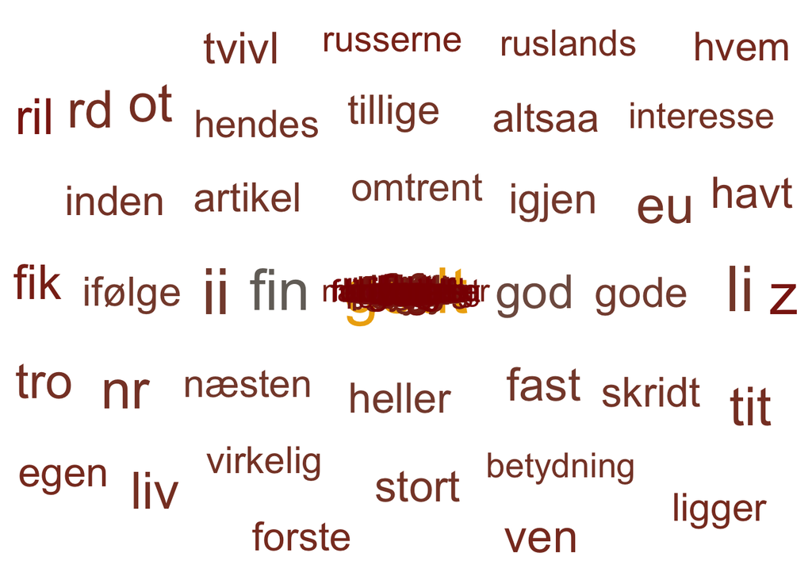

```r
ggplot(data = art_orienten_top_hundred, aes(label = word, size = n)) +
  geom_text_wordcloud_area(aes(color = n), shape = "diamond") +
  scale_size_area(max_size = 14) +
  scale_color_gradientn(colors = c("darkred","cadetblue4","darkgoldenrod2")) +
  theme_minimal()
```

## 4. Sentiment analysis with SENTIDA

The sentiments lexicon used in this project is SENTIDA created by Lars Kjartan Bacher Svendsen, Jacob Aarup Dalsgaard, and Gustav Aarup Lauridsen.

SENTIDA uses an 11-point coding scheme, where each point of the scale indicates the emotional charge of a word. A score of 0 is ‘neutral’, a score of -5 signifies ‘very strong negative emotion’, and a score of 5 signifies ‘very strong positive emotion’.[^1]

Link to SENTIDA github repository: https://github.com/Guscode/Sentida/tree/master

This next part of the project use SENTIDA as a tool to analyze the words that appear most frequently in connection with the term ‘Orienten’.

### 4.1 Installing SENTIDA

First step is to install SENTIDA.

```r
if(!require("devtools")) install.packages("devtools")
devtools::install_github("Guscode/Sentida")
library(Sentida)
```

The following snippet of code is needed to work with words containing the letters æ, ø, or å.

```r
Sys.setlocale(category = "LC_ALL", locale = "UTF-8")
```

```
## [1] "en_US.UTF-8/UTF-8/en_US.UTF-8/C/en_US.UTF-8/en_US.UTF-8"
```

### 4.2 Mean sentiment score

We will now be binding a mean sentiment score to each of the words in the `filtered_art_orienten` dataframe.

The first step is to use the `select()` function to subset the column `word` from the `filtered_art_orienten` dataframe. Next, is to utilize the `pull()` function to extract the `word` column as a vector.

```r
filtered_art_orienten_word <- filtered_art_orienten %>%
  select(word)

word <- filtered_art_orienten %>%
  pull(word)
```

Utilizing `lapply()`, we will now input the `word` vector as well as `sentida` and have the output be the mean score associated with the appropriate word. The `lapply()` function returns a list that is the same length as the input vector.[^2]

The `unlist()` function will simplify the list containing the sentiment score.[^3]

```r
filtered_art_orienten_word$sentiment <- lapply(filtered_art_orienten_word$word, sentida, output = "mean")

filtered_art_orienten_word$sentiment <- unlist(filtered_art_orienten_word$sentiment)

filtered_art_orienten_word
```

```
## # A tibble: 1,543,538 × 2
##    word    sentiment
##    <chr>       <dbl>
##  1 godt        2.67
##  2 fin         1.33
##  3 god         2.33
##  4 gode        2.33
##  5 omtrent     0
##  6 ii          0
##  7 heller      0.926
##  8 ifølge      0
##  9 igjen       0
## 10 fast        0
## # ℹ 1,543,528 more rows
```

### 4.2 Visualizing sentiments

One way to visualize the data above, is to count the sentiment scores and plotting them.

```r
faow_count <- filtered_art_orienten_word %>%
  count(sentiment)

faow_count
```

```
## # A tibble: 138 × 2
##    sentiment     n
##        <dbl> <int>
##  1     -5       26
##  2     -4.67    43
##  3     -4.33   153
##  4     -4      250
##  5     -3.83    46
##  6     -3.67   200
##  7     -3.62    18
##  8     -3.56    14
##  9     -3.5     41
## 10     -3.44     1
## # ℹ 128 more rows
```

[figure not shown]

```r
ggplot(data = faow_count, aes(x = sentiment, y = n)) +
  geom_col()
```

[^1]: Lauridsen, Gustav Aarup, Jacob Aarup Dalsgaard, and Lars Kjartan Bacher Svendsen. 2019. “SENTIDA: A New Tool for Sentiment Analysis in Danish”. Journal of Language Works - Sprogvidenskabeligt Studentertidsskrift 4 (1):38-53. https://tidsskrift.dk/lwo/article/view/115711.
[^2]: Datacamp, “lapply function - RDocumentation,” accessed December 18, 2023, https://www.rdocumentation.org/packages/base/versions/3.6.2/topics/lapply
[^3]: Datacamp, “unlist function - RDocumentation,” accessed December 18, 2023, https://www.rdocumentation.org/packages/base/versions/3.6.2/topics/unlist